# Combining Plots with {patchwork}

### Preparation

For this exercise, we will use the following three plots

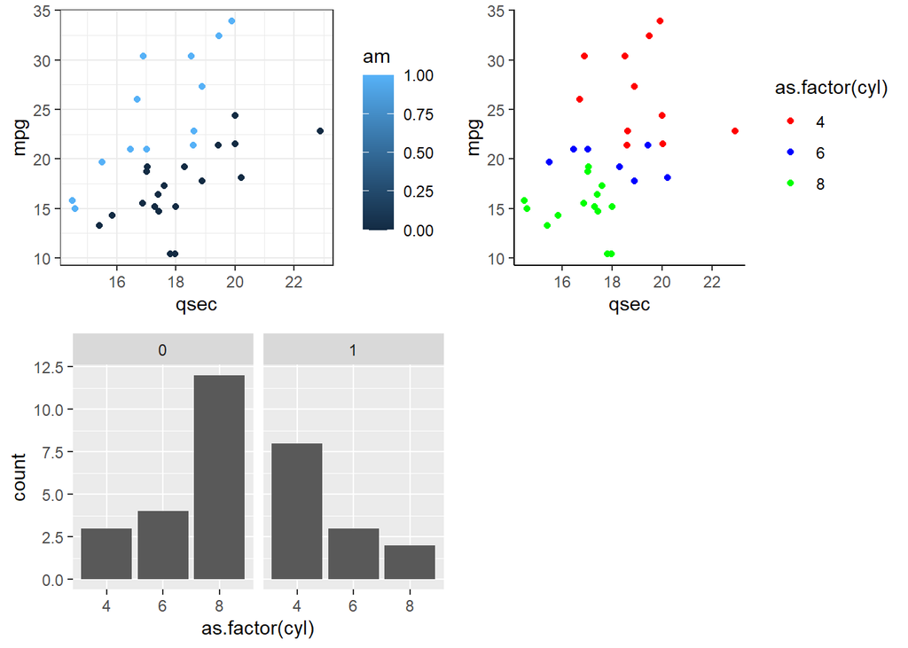

```r
p1 <- ggplot(mtcars, aes(qsec, mpg, color = am)) +
  geom_point() +
  theme_bw()


p2 <- ggplot(mtcars, aes(qsec, mpg, color = as.factor(cyl))) +
  geom_point() +
  scale_color_manual(values = c("red", "blue","green")) +
  theme_classic()


p3 <- ggplot(mtcars, aes(as.factor(cyl))) +
  geom_bar() +
  facet_wrap(~am)

gridExtra::grid.arrange(p1,p2,p3,ncol=2)
```

The patchwork package is useful for combining R plots together. With the patchwork package, plots can be combined using a few operators, such as “+”, “/”, and `“|”.

To combine two plots together we can simply add them together with the + sign or place them next to one another using the |:

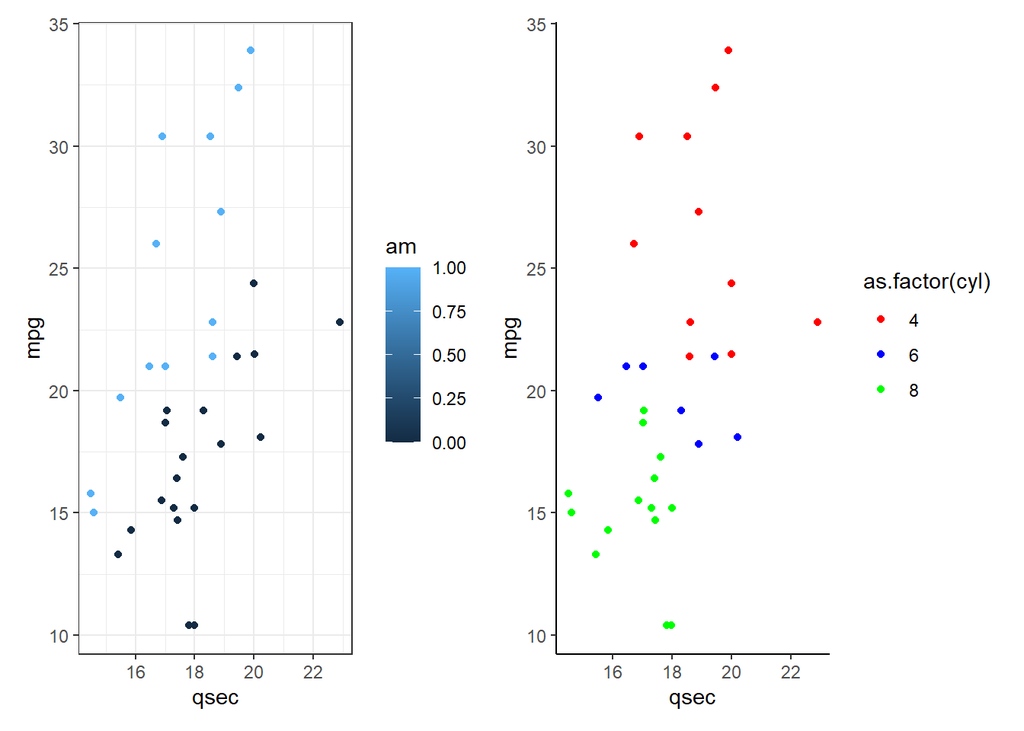

```r
#install.packages(patchwork)
library(patchwork)

p1 + p2
```

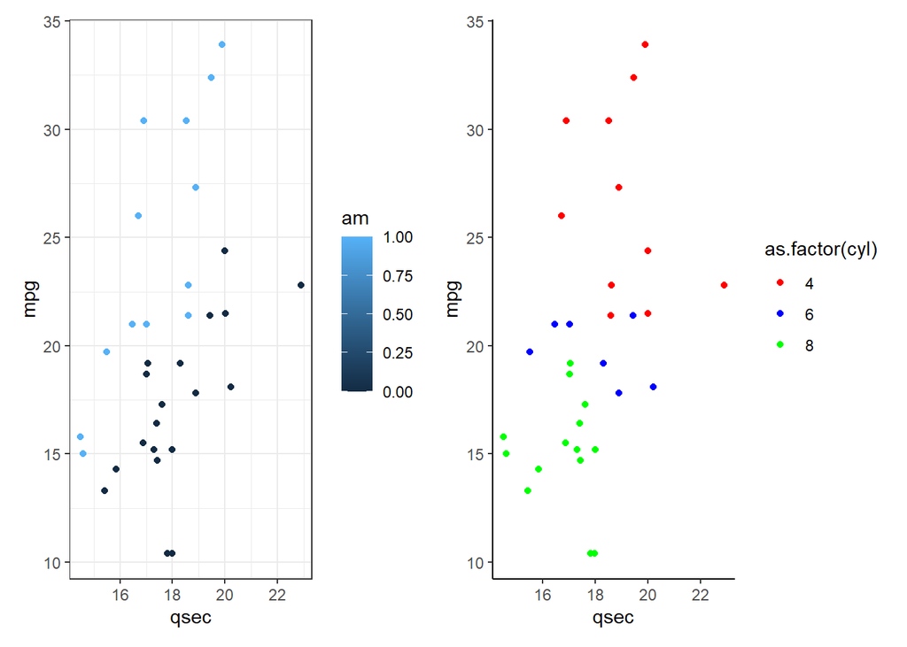

```r
p1 | p2
```

If we want a plot above another plot we can use the “/” symbol:

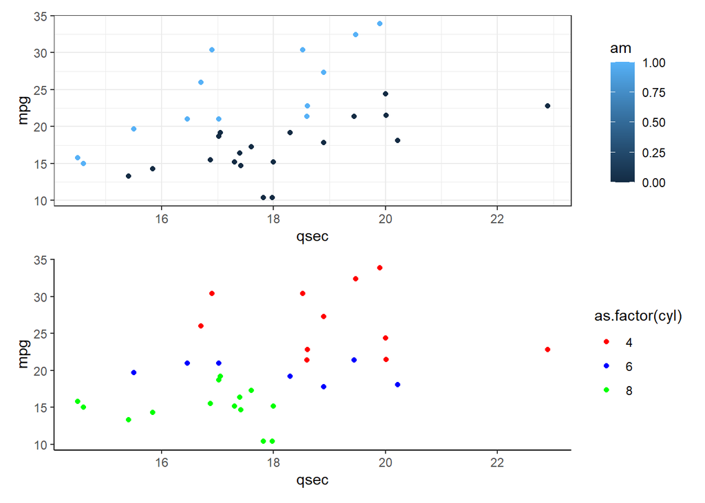

```r
p1 / p2
```

Grouping or nesting plots together using parenthesis can result in two or more plots taking up a single grid space.

Thus, to combine multiple plots in a more complicated layout, one can combine two plots on one row and have a third plot on another row like this:

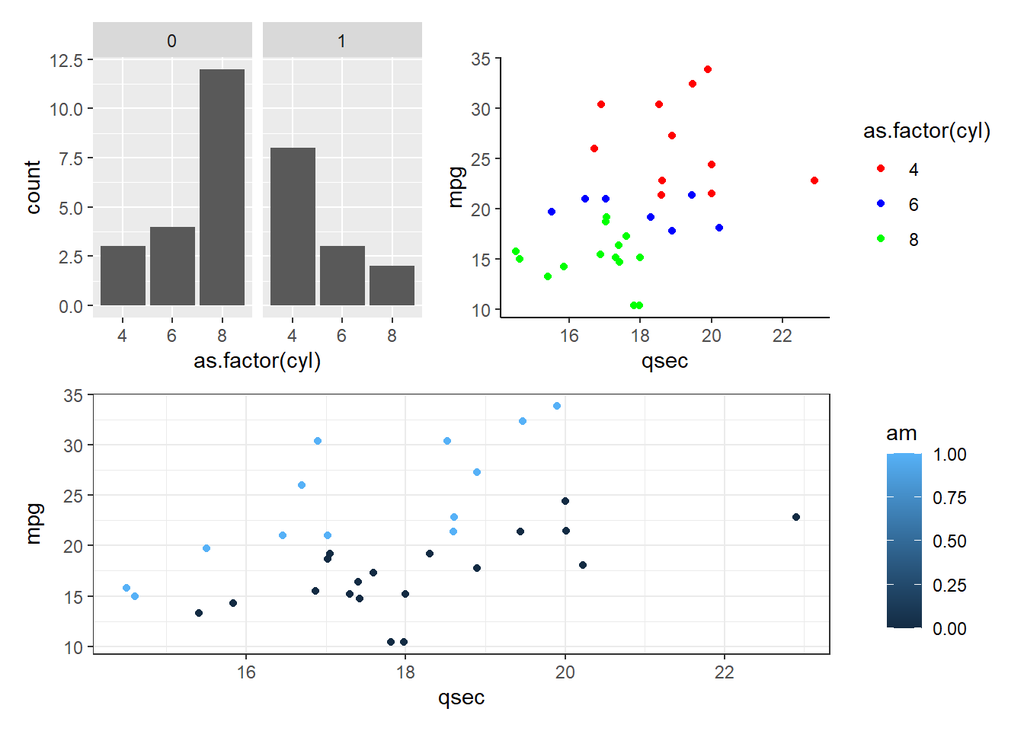

```r
(p3 + p2) / p1
```

Without the parentheses we would have the following:

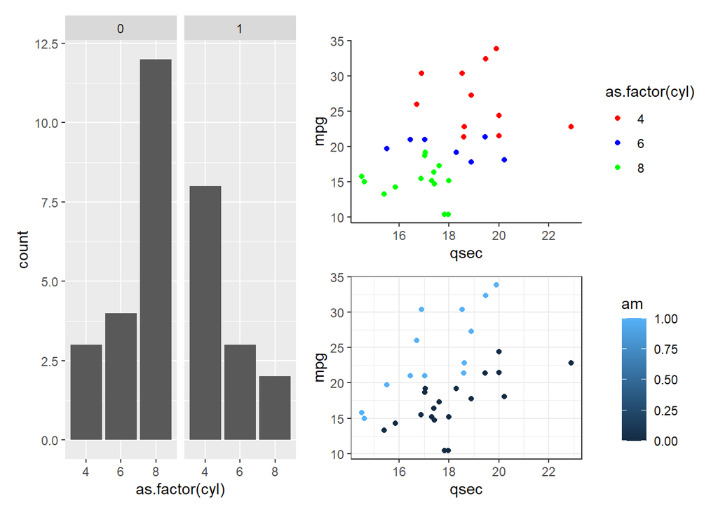

```r
p3 + p2 / p1
```

You can also empty plot spacers using the plotspacer() function like so:

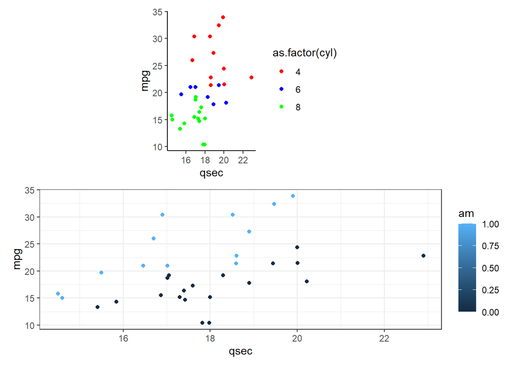

```r
(plot_spacer() + p2 + plot_spacer()) / p1
```

You can modify the widths of the plots using the widths argument of the plot_layout() function. In the following example we will make the width of the plot on the left 2 times that of the plot on the right. Any numeric values will do, it is the ratio of the numbers that make the difference.

Thus, both `p1 + p2 + plot_layout(widths = c(2, 1))` and `p1 + p2 + plot_layout(widths = c(60, 30))` will result in the same relative size difference between p1 and p2.

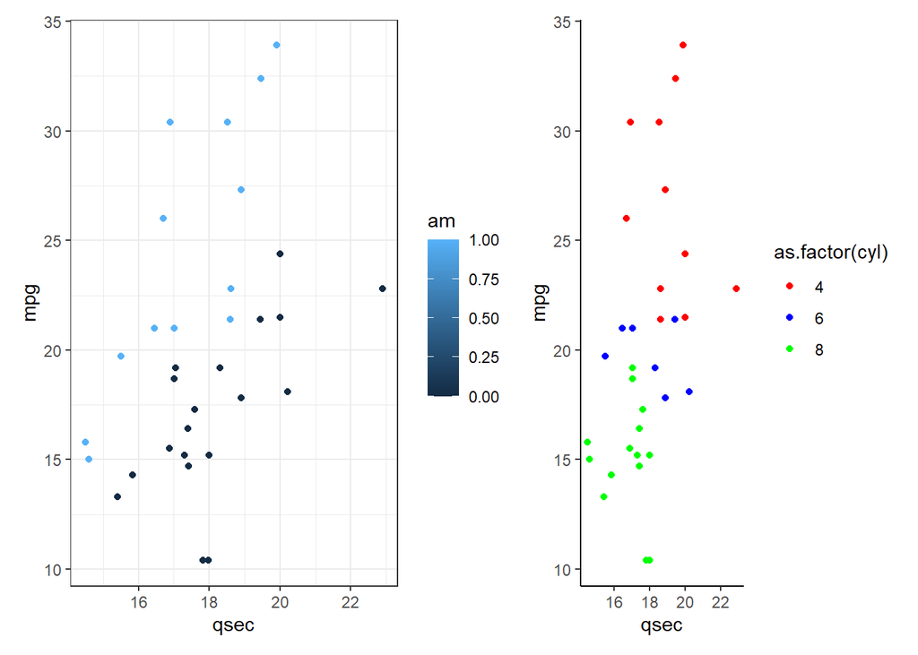

```r
p1 + p2 + plot_layout(widths = c(60, 30))
```

The relative heights of the plots can also be modified using a heights argument with the same function.

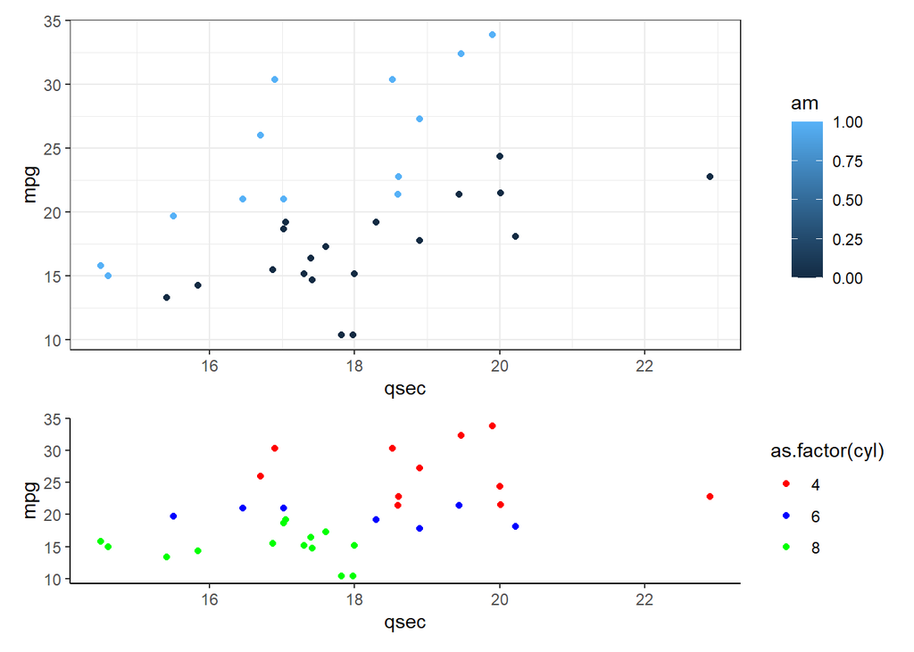

```r
p1 + p2 + plot_layout(heights = c(2, 1))
```

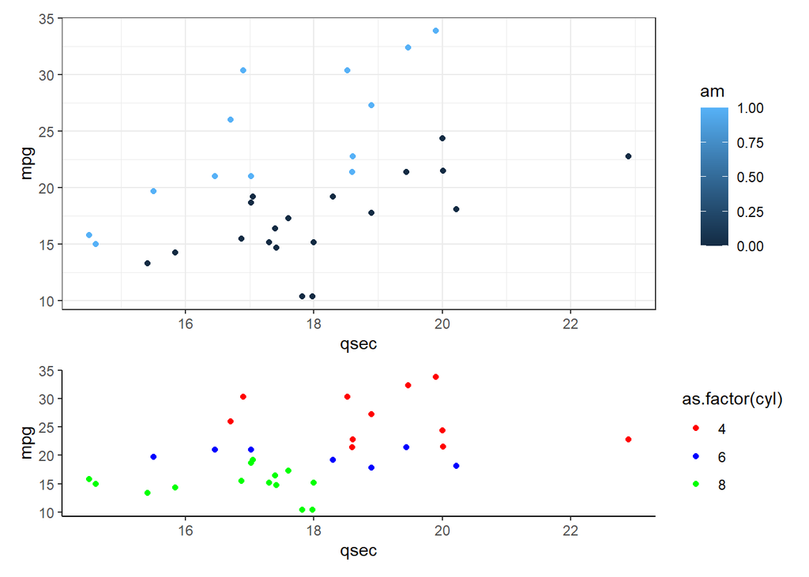

```r
p1 + p2 + plot_layout(heights = c(60, 30))
```

This package also allows for modification of legends. For example, legends can be gathered together to one side of the combined plots using the guides = ‘collect’ argument of the plot_layout() function.

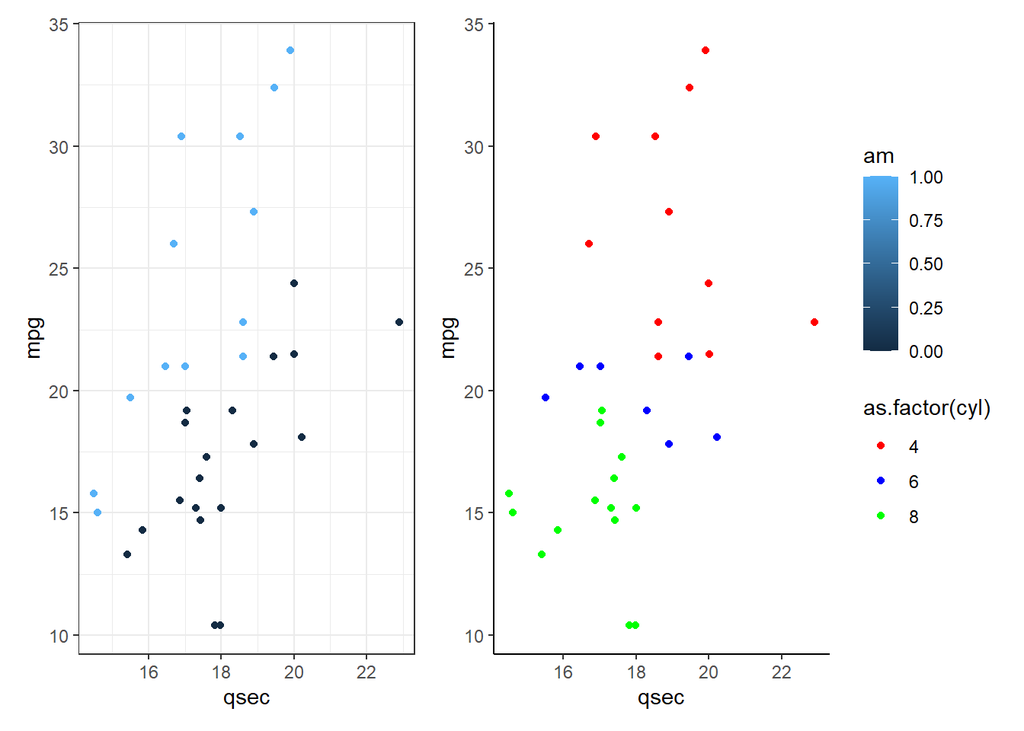

```r
p1 + p2 + plot_layout(guides = "collect")
```

You can also specify the number of columns or rows using this same function with ncol or nrow as you would with facet_wrap() of the ggplot2 package, where plots are added to complete a row before they will be added to a new row. For example, the following will result in an empty 2nd row below the plots.

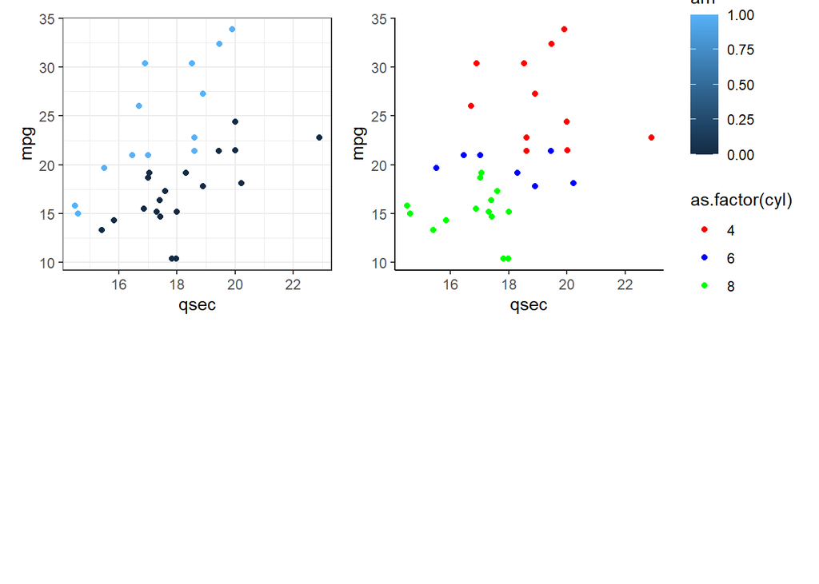

```r
p1 + p2 + plot_layout(nrow = 2, ncol = 2, guides = "collect")
```

However, the byrow = FALSE argument can disrupt this behavior and result in an empty 2nd column:

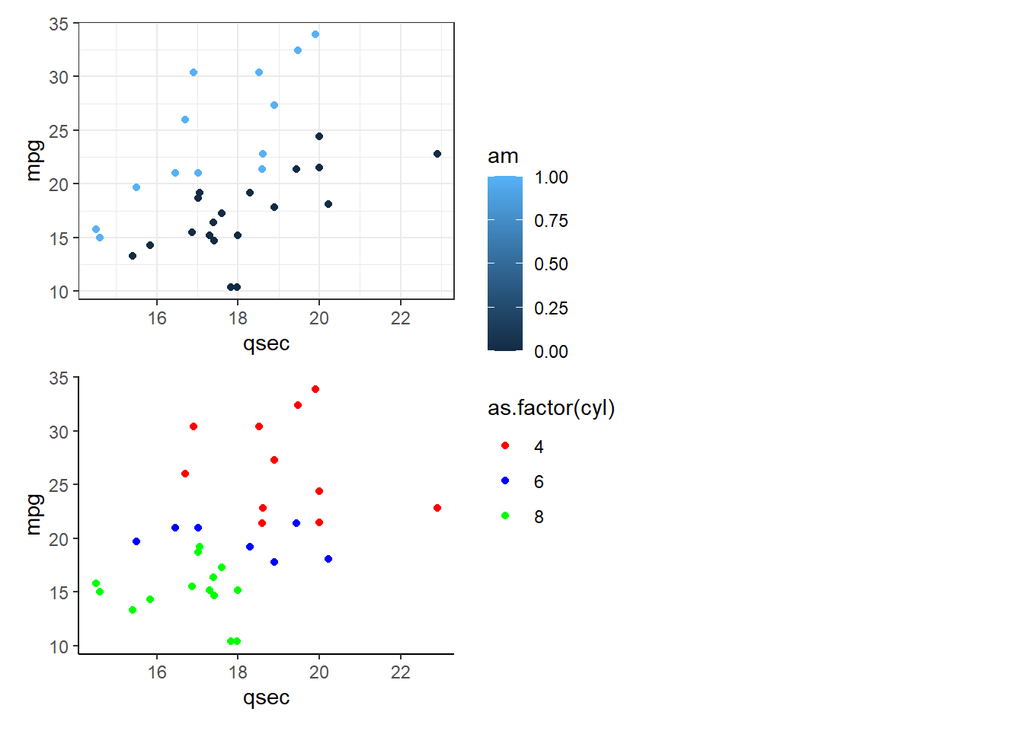

```r
p1 +p2 + plot_layout(nrow = 2, ncol = 2, byrow = FALSE, guides = "collect")
```

In this case the columns will be preferentially completed before placing a plot in a new column.

We can also use the package to change the theme specifications of specific plots. By default the plot just prior to the theme() function will be the only plot changed.

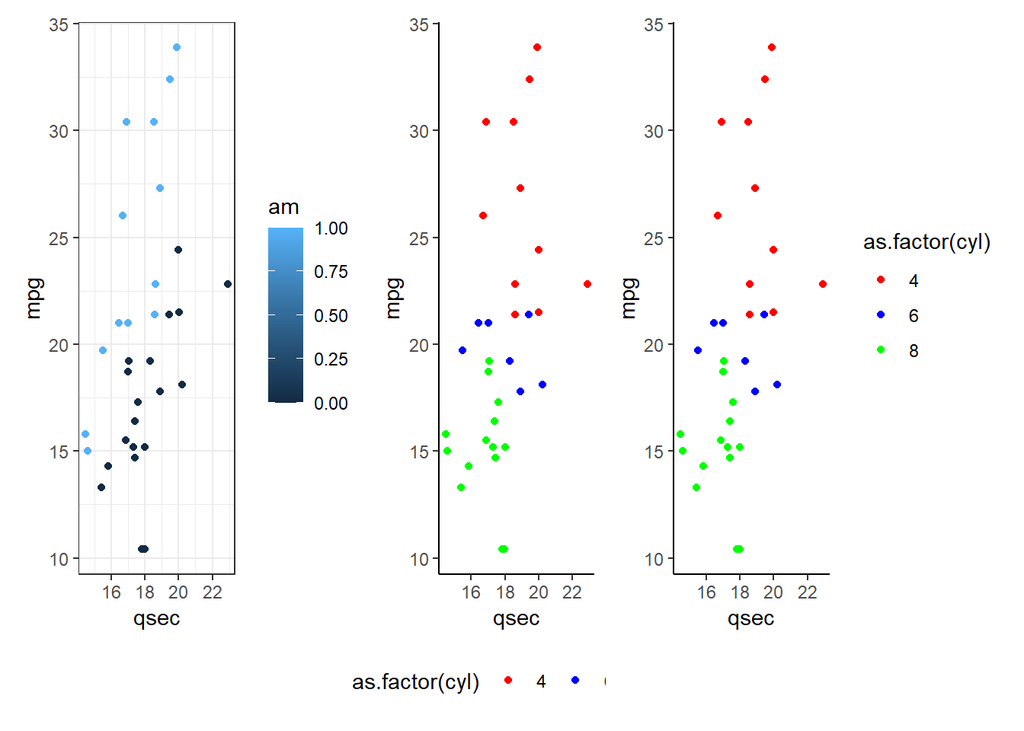

```r
p1 + p2 + theme(legend.position = "bottom") + p2
```

Using the *, themes can be added to all plots that are nested together.

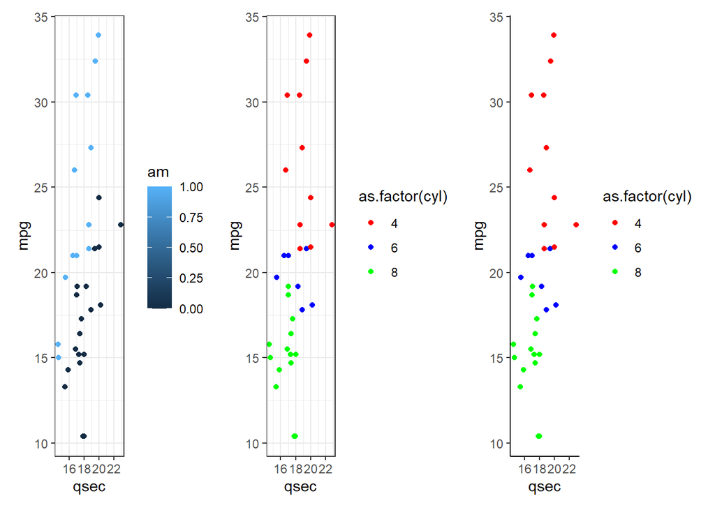

```r
(p1 + p2) *theme_bw() + p2
```

The & adds themes to all plots.

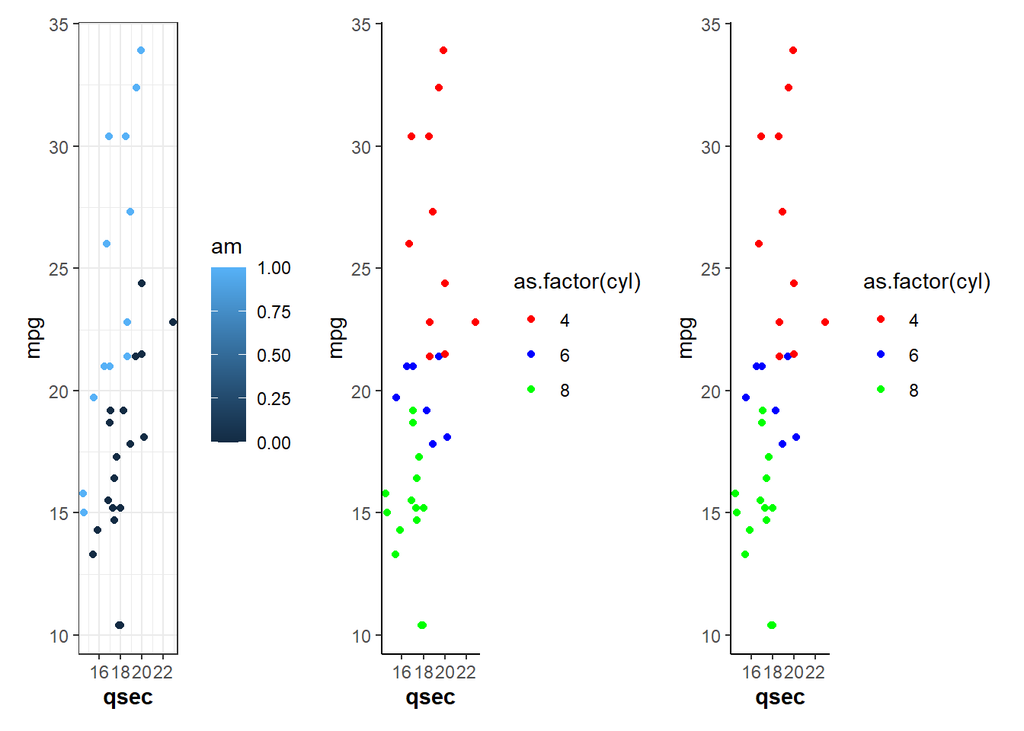

```r
(p1 + p2) + p2 & theme(axis.title.x = element_text(face = "bold"))
```

Annotations for all the plots combined can also be added using the plot_annotation() function, which can also take theme() function specifications with the theme argument.

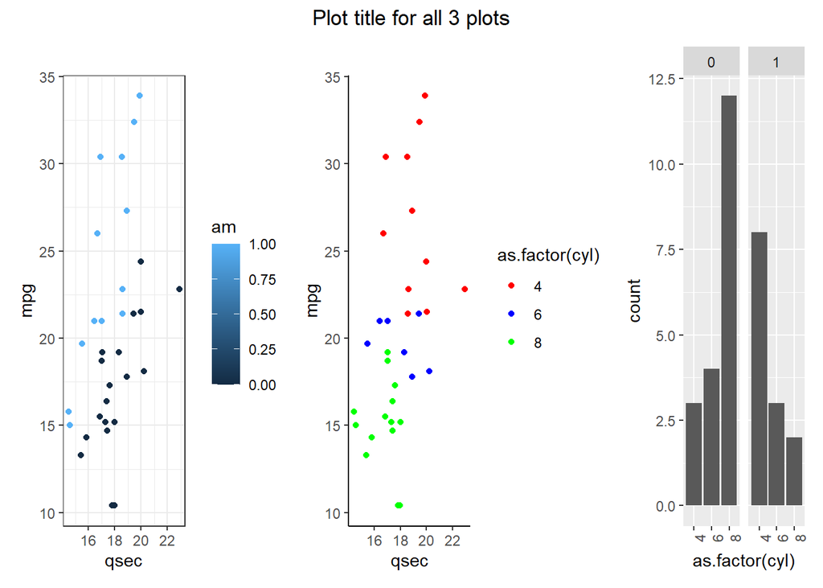

```r
(p1 + p2) + p3 + theme(axis.text.x = element_text(angle = 90)) +
  plot_annotation(title = "Plot title for all 3 plots",
                  theme = theme(plot.title = element_text(hjust = 0.5)))
```